# Семинар для товарищей-магистров

Москвин Дмитрий

2 декабря 2017г.

# Введение в бутстрэп

[figure not shown]

Что есть bootstrap?

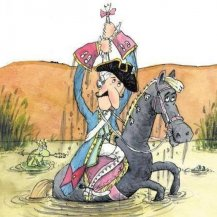

Как работает bootstrap?

## Немного теории

Бутстрэп — практический компьютерный метод исследования распределения статистик вероятностных распределений, основанный на многократной генерации выборок методом Монте-Карло на базе имеющейся выборки.

Термин введен в 1977г. Брэдли Эфроном (первая публикация относится к 1979г., статья “Bootstrap Methods: Another Look at the Jackknife”).

Входит в класс методов генерации повторной выборки (jackknife, cross-validation, exact-test). Суть метода состоит в том, чтобы по имеющейся выборке построить эмпирическое распределение (приближение теоретической функции распределения).

Если о законе распределения выборки нет никаких априорных сведений, а получить оценки его характеристики все-таки необходимо, то bootstrap-метод может быть весьма полезным инструментом. По сути это “нечестный метод” в статистике, который позволяет получить примерный ответ на многие практические вопросы без анализа, грубой компьютерной силой.

## Алгоритм

1. Выбираем наугад одно наблюдение из имеющихся;
2. Повторяем пункт 1 столько раз, сколько у нас есть наблюдений (выбор происходит с повторением);
3. Считаем интересующие нас метрики по этой новой выборке, запоминаем результат;
4. **Повторяем пункты 1-3 B раз**.

# Практика

Данные, с которыми будем работать, можно скачать отсюда: [данные об автостоянках, паркингах и гаражах Санкт-Петербурга](http://data.gov.spb.ru/opendata/43/versions/11/csv/). Нам предстоит построить доверительный интервал “вместимости” средней платной парковки в Санкт-Петербурге.

В датасете уберем поля number и note, чтобы не все выглядело громоздко, и посмотрим, с чем предстоит работать:

```r
auto_spb <- as.data.table(auto_spb)[,2:7]

datatable(auto_spb,class = 'cell-border stripe',rownames = FALSE,
          options = list(lengthChange = FALSE, pageLength = 5),
          caption = 'Таблица 1: Данные о парковках Санкт-Петербурга.')
```

| address | type | parking_space | area | district_city | nearest_subway_station |
| --- | --- | --- | --- | --- | --- |
| 194362, Санкт-Петербург, проспект Энгельса, у д. 162, литера Р | Перехватывающая | 155 | 4500 | Выборгский | Парнас |
| 194358, Санкт-Петербург, проспект Просвещения, у д. 30, корпус 1 | Перехватывающая | 43 | 1319 | Выборгский | Проспект Просвещения |
| 195267, Санкт-Петербург, Гражданский проспект, у д. 116, корпус 1 | Перехватывающая | 46 | 1423 | Калининский | Гражданский проспект |
| 194064, Санкт-Петербург, Политехническая улица, у д. 29, литера П | Перехватывающая | 61 | 1413 | Калининский | Политехническая |
| 198097, Санкт-Петербург, проспект Стачек, у д. 47, литера Ф | Перехватывающая | 50 | 2722 | Кировский | Кировский завод |
| 198260, Санкт-Петербург, проспект Народного Ополчения, у д. 16 | Перехватывающая | 190 | 5814 | Кировский | Ленинский проспект |
| 195112, Санкт-Петербург, Заневский проспект, у д. 65, литера А | Перехватывающая | 117 | 5200 | Красногвардейский | Ладожская |
| 196233, Санкт-Петербург, Витебский проспект, у д. 90, литера А | Перехватывающая | 93 | 2482 | Московский | Купчино |
| 196233, Санкт-Петербург, Витебский проспект, у д. 108, литера А | Перехватывающая | 99 | 3741 | Московский | Купчино |
| 192012, Санкт-Петербург, улица Грибакиных, у д. 27, литера А | Перехватывающая | 330 | 9764 | Невский | Обухово |

[output cut: 234 more lines]

Выберем лишь наблюдения с типом парковки *платная* и посмотрим на гистограмму парковочных мест:

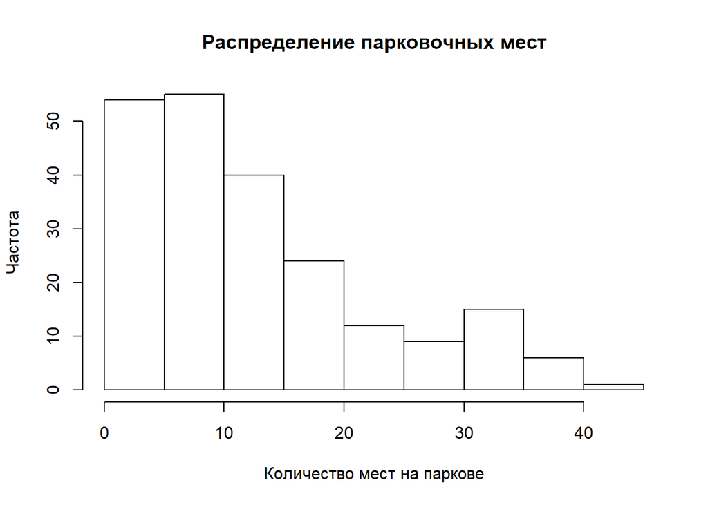

```r
auto_spb_pay <- auto_spb[type == "Платная",]

hist(auto_spb_pay$parking_space,
     xlab = "Количество мест на паркове",
     ylab = "Частота",
     main = "Распределение парковочных мест")
```

## “Бутстрапированный” доверительный интервал со стандартной ошибкой

1. Рассмотрим для начала реальное значение среднего для парковочного места

```r
parking_space.mean = with(auto_spb_pay, mean(parking_space))
parking_space.mean
```

```
[1] 13.28241
```

```r
B = 1000
n = nrow(auto_spb_pay)
boot.samples = matrix(sample(x = auto_spb_pay$parking_space,
                             size = B*n,
                             replace = TRUE),
                      nrow = B,
                      ncol = n)
boot.statistics = apply(boot.samples, 1, mean)
```

Визуализируем распределение средних значений наших выборок:

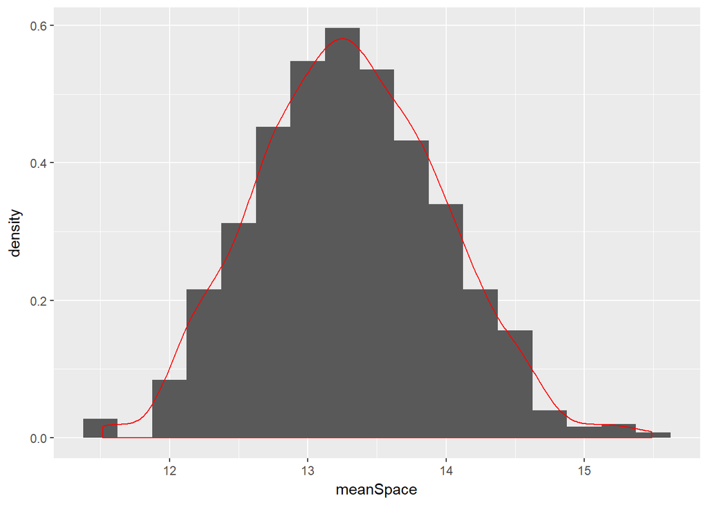

```r
ggplot(data.frame(meanSpace = boot.statistics),aes(x=meanSpace)) +
geom_histogram(binwidth=0.25,aes(y=..density..)) +
geom_density(color="red")
```

Посчитаем 95% доверительный интервал

```r
space.se = sd(boot.statistics)
interval = round(parking_space.mean + c(-1,1)*2*space.se,2)

cat("Нижняя граница:  ", interval[1], "\nВерхняя граница: ", interval[2])
```

```
Нижняя граница:   11.95
Верхняя граница:  14.62
```

Обернем все в функцию:

```r
boot.mean <-  function(x,B,binwidth=NULL, percent = FALSE){
  n = length(x) # количество реальных наблюдений
  boot.samples = matrix(sample(x,size=n*B,replace=TRUE), B, n) # делаем сэмплирование с повторением
  boot.statistics = apply(boot.samples,1,mean) # считаем интересующую статистику
  se = sd(boot.statistics) # считаем стандартное отклонение
  require(ggplot2) # подключаем библиотеку для отрисовки графика
  if(is.null(binwidth)){binwidth = diff(range(boot.statistics))/30} # задаем ширину столбцов на графике
  p = ggplot(data.frame(x=boot.statistics),aes(x=x)) +
    geom_histogram(aes(y=..density..),binwidth=binwidth) + geom_density(color="red")
  plot(p)
  if(percent){
    interval = round(mean(x) + c(-1,1)*2*se,4) # считаем доверительный 95% интервал
    cat("Нижняя граница:  ", 100* interval[1], "%\nВерхняя граница: ", 100*interval[2],"%")
  } else {
    interval = round(mean(x) + c(-1,1)*2*se,2) # считаем доверительный 95% интервал
    cat("Нижняя граница:  ", interval[1], "\nВерхняя граница: ", interval[2])
    }
  return(list(boot.statistics = boot.statistics, interval=interval, se=se, plot=p))
}
```

```r
out <- boot.mean(auto_spb_pay$parking_space, B = 10000)
```

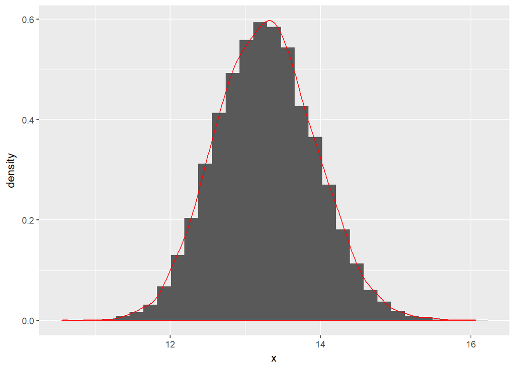

```
Нижняя граница:   11.97
Верхняя граница:  14.6
```

## Требовать ли премию?

В компании провели эксперимент с оффером. Через определенное время t измерили конверсию и пришли к выводу, что все отлично!

Вот данные эксперимента:

Было 2618 новых пользователей –> зарегестрировалось 62 |конверсия = 2,37%

Стало 2417 новых пользователей –> зарегестрировалось 70 |конверсия = 2,90%

Воспользуемся инструментом, который мы только что освоили:

```r
new_offer <- c(rep(1, 70), rep(0, 2417 - 70))
new_offer_result <- boot.mean(new_offer, 10000,binwidth = 0.001,percent = TRUE)
```

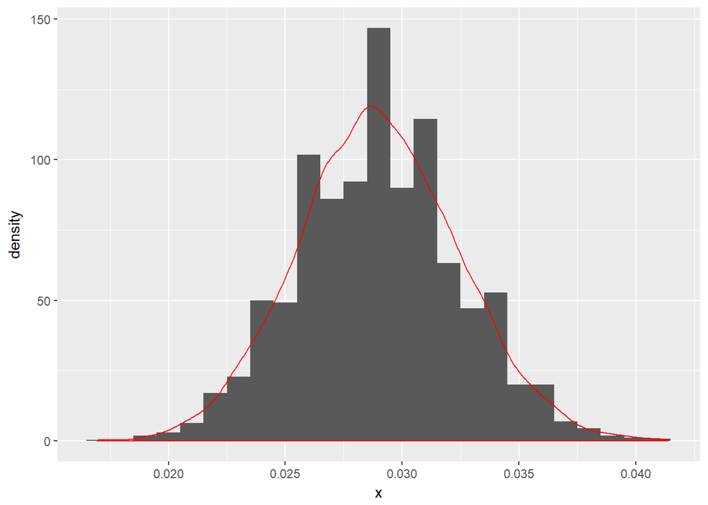

```
Нижняя граница:   2.21 %
Верхняя граница:  3.59 %
```

## Package ‘boot’

Мы самостоятельно реализовали простенькую функцию бутстрэпирования и понимаем, что это такое и зачем оно нужно. Выдохнем. Теперь начнем пользваться готовой библиотекой, с помощью которой можно познать всю мощь инструмента ( **?boot()** ).

Выполним уже знакомую процедуру с помощью пакета:

```r
my.mean <- function(x, indices) {
  return( mean( x[indices] ) )
}

space.boot <- boot(auto_spb_pay$parking_space, my.mean, 10000)
boot.ci(space.boot, type = "basic")
```

```
BOOTSTRAP CONFIDENCE INTERVAL CALCULATIONS
Based on 10000 bootstrap replicates

CALL :
boot.ci(boot.out = space.boot, type = "basic")

Intervals :
Level      Basic
95%   (11.97, 14.59 )
Calculations and Intervals on Original Scale
```

# Отступление или *“что еще интересного я могу поведать”*

Что я делаю на работе и каким набором data-сатаниста я пользуюсь:

[data.table](https://cran.r-project.org/web/packages/data.table/vignettes/datatable-intro.html) OR [dplyr](https://cran.r-project.org/web/packages/dplyr/vignettes/dplyr.html) - стиль и скорость работы с данными

[lubridate](https://www.rdocumentation.org/packages/lubridate/versions/1.7.0) - работа с датами

[microbenchmark](https://www.r-bloggers.com/using-the-microbenchmark-package-to-compare-the-execution-time-of-r-expressions/) - анализ скорости выполнения кода

[xgboost](https://cran.r-project.org/web/packages/xgboost/vignettes/xgboostPresentation.html) - модель стохастического градиентного спуска

[caret](http://topepo.github.io/caret/index.html) - пакет с реализацией большинства алгоритмов data science

[RODBC](https://www.statmethods.net/input/dbinterface.html) - коннектор к базе данных

[ggplot](http://ggplot2.tidyverse.org/reference/index.html) - бесподобная визуализация данных

vkR - анализ данных ВКонтакте

[jsonlite](https://cran.r-project.org/web/packages/jsonlite/vignettes/json-aaquickstart.html) - работа с древовидным типом данных json

[stringr](https://cran.r-project.org/web/packages/stringr/vignettes/stringr.html) - работа с текстом

…

## Тестируем скорость библиотек

1. Подготовим данные для тестирования.

```r
write.csv(x = auto_spb_pay, "auto_spb.csv",row.names = F,fileEncoding = "UTF-8")
date_data <- as.character( seq.Date(from = as.Date("2010-01-01"),to = Sys.Date(),by = 'day') )
```

2. Сравним fread() из пакета **data.table** с read.table() из базового пакета:

```r
compare_1 <- microbenchmark(data.table = fread("auto_spb.csv",stringsAsFactors = F),
                                 basic = read.table("auto_spb.csv",stringsAsFactors = F,sep = ",",header = T),
                                 times = 1000L)
summary(compare_1)[1:7]
```

```
        expr      min       lq      mean   median       uq       max
1 data.table  596.255  640.001  787.7733  686.719  780.828 26878.111
2      basic 1705.318 1761.891 1950.0038 1810.634 1907.309  7968.136
```

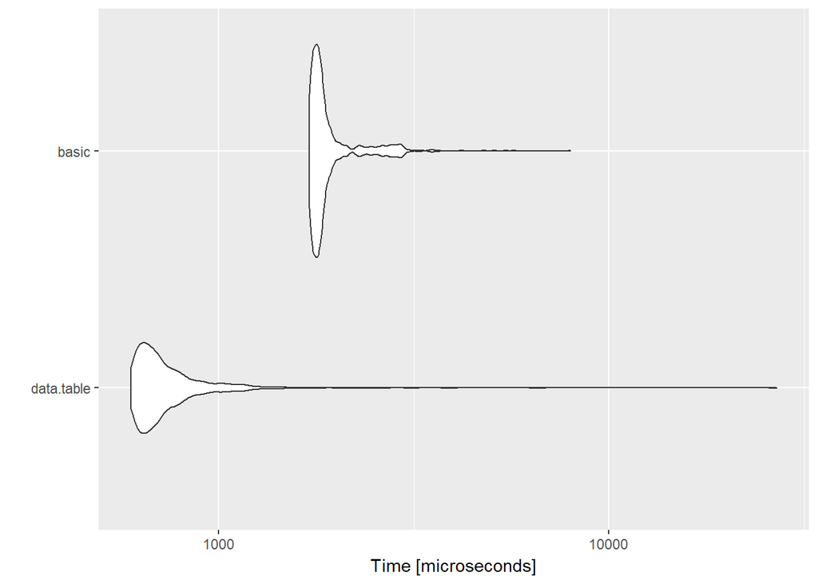

```r
autoplot(compare_1)
```

3. Сравним ymd() из пакета **lubridate** с as.Date() из базового пакета:

```r
compare_2 <- microbenchmark(lubridate = ymd(date_data),
                            basic = as.Date(date_data),
                            times = 1000L)
summary(compare_2)[1:7]
```

```
       expr       min        lq      mean    median        uq       max
1 lubridate  3.148963  3.287495  3.687884  3.414955  3.517841 105.39693
2     basic 13.913115 14.078786 14.589345 14.169115 14.372321  21.77782
```

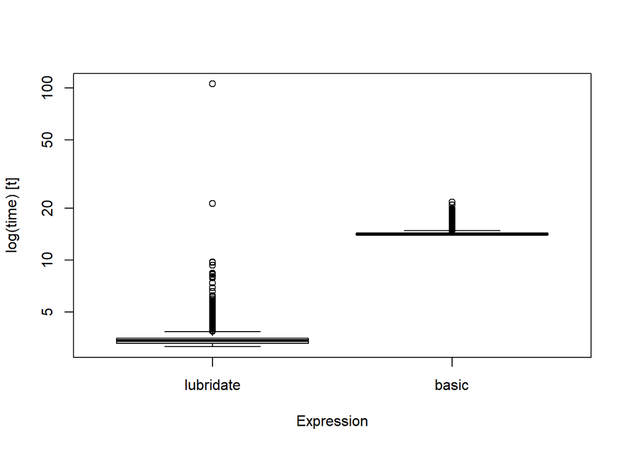

```r
boxplot(compare_2)
```

На этом примере **lubridate** работает >= 3.5 раза лучше!

# Вывод

0. Прогайте, друзья
1. Сначала пробуйте строить класс/функцию ручками
2. Если как-то не зашло, то читайте теорию
3. Если все получилось, то юзайте библиотеки

## Ссылочки

1. Вот статья, с которой началось мое знакомство с этим методом: [вдохновение бутстрэпом](https://habrahabr.ru/post/192000/).
2. Если я рассказал плохо, или вы прослушали, можно глянуть эту [ссылку](https://stepik.org/lesson/42820/step/1?unit=20941). Здесь коллеги из института биоинформатики посвятили один из модулей курса бутстрэпу.
3. Еще лучше зайти [сюда](https://www.statmethods.net/advstats/bootstrapping.html) и посмотреть фрагмент неплохой книги *R in Action / Advanced statistics with R.*